# Covid Prediction

Alex Olmeta, Alex Paine, Donald Stricklin

## Project Overview

- The world was not ready for the severe impact of COVID-19.
- 7,010,568 Reported COVID-19 deaths (as of 12/31/23)
- Models on disease growth at the time were poorly equipped to stifle the spread of this deadly disease
- This project has the potential to evaluate where a country stands in terms of projected death rate, thereby reinforcing or introducing new methods to prevent the spread, and thus, preventing the loss of innocent lives.

## Objectives

*To Create a Predictive Model to Predict the Number of Deaths of an Unseen Country*

- Assess the model’s predictive performance by evaluating its accuracy, precision, recall, and other relevant metrics.
- Model has application for both future COVID-19 variants + future similar diseases
- Our proposed model would take several weeks of prior data on a previously unseen country and predict the number of deaths in the coming weeks.

## The Data

- Comprehensive scope of COVID-19 metrics, including cases, deaths, vaccinations, and ICU admissions for 200+ countries/territories
- After initial preprocessing, have 255,000 observations and 67 variables
- Significant missingness issues - total cases reported every week, not day.
- Some countries also do not provide ICU and vaccination rates making them harder to work with

## Visualizing the Amount of New Deaths

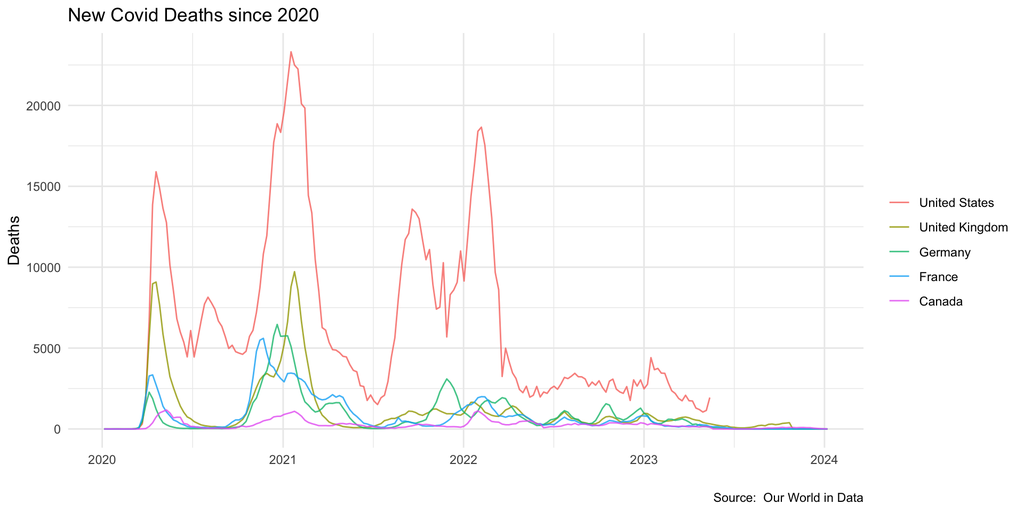

## Cleaning and Preprocessing

- Data was already largely preprocessed and came in one neat `.csv` file
- Had to remove ~20,000 rows of regional summary information (e.g., case data for Europe) as these were redundant
- Fair amount of missing data will need to be imputed (daily vs. weekly)
- Some predictors are correlated

## Conclusion

- Develop model based on daily COVID-19 data from the last 4 years that predicts the number of deaths in a country
- We anticipate fewer deaths all over the world in the near future as COVID-19 has been trending downward
- Challenges
  - Predictor selection
  - Missing data
  - Computation time

## Citations

- World Health Organization 2023 data.who.int, WHO Coronavirus (COVID-19) dashboard > Deaths [Dashboard]. https://data.who.int/dashboards/covid19/deaths
- Mathieu, E., Ritchie, H., Ortiz-Ospina, E. et al. A global database of COVID-19 vaccinations. Nat Hum Behav (2021). https://doi.org/10.1038/s41562-021-01122-8